# NYC flight delays: time of day matters more than the weather

Author

Olorunmaiye Peter

## Business question

Late departures cost airlines crew time, missed connections and unhappy passengers. **Which flights leaving New York leave late, and how much of that is down to the weather rather than things the airline controls, like the time of day a flight is scheduled?**

**Data:** every flight that left JFK, LaGuardia and Newark in 2023 (U.S. Bureau of Transportation Statistics), with hourly weather at each airport (Iowa Environmental Mesonet), from the `nycflights23` R package.

A flight counts as **late** if it left 15 minutes or more after its scheduled time, the standard used by the U.S. Department of Transportation.

## 1. Setup

```r
library(tidyverse)     # dplyr, ggplot2, forcats, tidyr
library(nycflights23)  # flights, weather, airlines
library(broom)         # tidy model output

dir.create("charts", showWarnings = FALSE)

orange <- "#e8603c"
navy   <- "#13263f"
grey   <- "#c9ced6"
theme_set(theme_minimal(base_size = 12))
```

## 2. Load and check the data

```r
cat("Flights:", nrow(flights), " Weather hours:", nrow(weather),
    " Airlines:", nrow(airlines), "\n")
```

```
Flights: 435352  Weather hours: 26207  Airlines: 14
```

```r
# A flight with no departure time never left: it was cancelled
summary_counts <- flights |>
  summarise(flights   = n(),
            cancelled = sum(is.na(dep_time)),
            pct_cancelled = round(100 * cancelled / flights, 1))
summary_counts
```

```
# A tibble: 1 x 3
  flights cancelled pct_cancelled
    <int>     <int>         <dbl>
1  435352     10738           2.5
```

```r
# Keep flights that left, and mark the late ones
departed <- flights |>
  filter(!is.na(dep_delay)) |>
  left_join(airlines, by = "carrier") |>
  rename(airline = name) |>
  mutate(late = dep_delay >= 15)

departed |>
  summarise(departed = n(),
            pct_late = round(100 * mean(late), 1),
            avg_delay_mins = round(mean(dep_delay), 1),
            median_delay_mins = median(dep_delay))
```

```
# A tibble: 1 x 4
  departed pct_late avg_delay_mins median_delay_mins
     <int>    <dbl>          <dbl>             <dbl>
1   424614     21.6           13.8                -2
```

**Check:** 435,352 flights, 10,738 cancelled (2.5%); of the 424,614 that left, 21.6% were late. The median delay is negative: most flights leave a little early.

## 3. When are flights late?

### Delays build up through the day

```r
by_hour <- departed |>
  group_by(hour) |>
  summarise(flights = n(), pct_late = 100 * mean(late)) |>
  filter(flights >= 1000)          # leaves out hours with very few flights
by_hour |> mutate(pct_late = round(pct_late, 1)) |> print(n = Inf)
```

```
# A tibble: 18 x 3
    hour flights pct_late
   <dbl>   <int>    <dbl>
 1     5    3218     10.5
 2     6   28448      8.9
 3     7   29481     11
 4     8   28671     13.1
 5     9   31227     14.3
 6    10   23455     16.4
 7    11   25766     15.5
 8    12   21131     17.5
 9    13   23911     20.8
10    14   26126     23.5
11    15   28550     25.4
12    16   25714     26
13    17   26847     29.2
14    18   25103     29.8
15    19   26531     32.5
16    20   23525     33.4
17    21   19752     31.7
18    22    6893     35.8
```

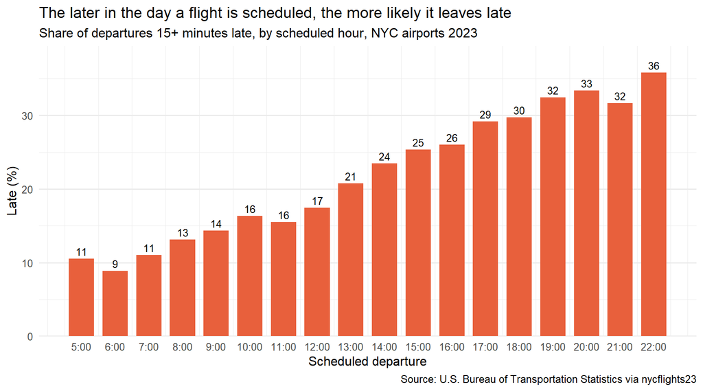

```r
p_hour <- ggplot(by_hour, aes(x = hour, y = pct_late)) +
  geom_col(fill = orange, width = 0.75) +
  geom_text(aes(label = round(pct_late)), vjust = -0.4, size = 3.4) +
  scale_x_continuous(breaks = 5:22, labels = \(h) paste0(h, ":00")) +
  scale_y_continuous(expand = expansion(mult = c(0, 0.1))) +
  labs(title = "The later in the day a flight is scheduled, the more likely it leaves late",
       subtitle = "Share of departures 15+ minutes late, by scheduled hour, NYC airports 2023",
       x = "Scheduled departure", y = "Late (%)",
       caption = "Source: U.S. Bureau of Transportation Statistics via nycflights23") +
  theme(panel.grid.major.x = element_blank())
p_hour
```

```r
ggsave("charts/late_by_hour.png", p_hour, width = 9, height = 5, dpi = 150, bg = "white")
```

### Airlines and airports

```r
by_airline <- departed |>
  group_by(airline) |>
  summarise(flights = n(), pct_late = 100 * mean(late)) |>
  filter(flights >= 5000) |>
  arrange(pct_late)
by_airline |> mutate(pct_late = round(pct_late, 1))
```

```
# A tibble: 10 x 3
   airline                flights pct_late
   <chr>                    <int>    <dbl>
 1 Republic Airline         85723     12.5
 2 Endeavor Air Inc.        52380     16
 3 American Airlines Inc.   39940     18.2
 4 Alaska Airlines Inc.      7774     20.3
 5 SkyWest Airlines Inc.     6214     21.4
 6 Delta Air Lines Inc.     60616     21.4
 7 Spirit Air Lines         14827     25.9
 8 United Air Lines Inc.    77810     26.1
 9 Southwest Airlines Co.   12105     28.5
10 JetBlue Airways          64622     32.3
```

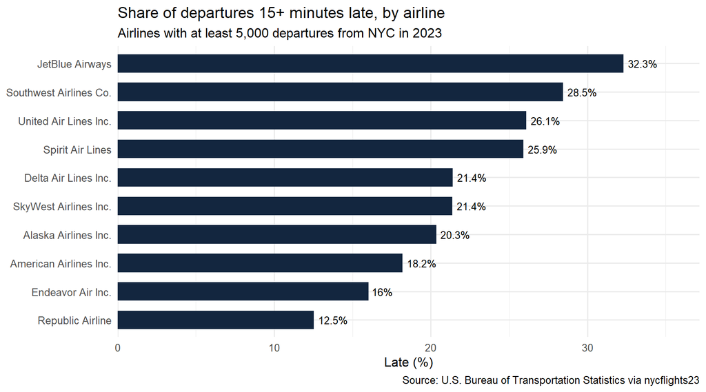

```r
p_airline <- ggplot(by_airline, aes(x = pct_late, y = reorder(airline, pct_late))) +
  geom_col(fill = navy, width = 0.65) +
  geom_text(aes(label = paste0(round(pct_late, 1), "%")), hjust = -0.15, size = 3.4) +
  scale_x_continuous(expand = expansion(mult = c(0, 0.15))) +
  labs(title = "Share of departures 15+ minutes late, by airline",
       subtitle = "Airlines with at least 5,000 departures from NYC in 2023",
       x = "Late (%)", y = NULL,
       caption = "Source: U.S. Bureau of Transportation Statistics via nycflights23")
p_airline
```

```r
ggsave("charts/late_by_airline.png", p_airline, width = 9, height = 5, dpi = 150, bg = "white")

departed |>
  group_by(origin) |>
  summarise(flights = n(), pct_late = round(100 * mean(late), 1))
```

```
# A tibble: 3 x 3
  origin flights pct_late
  <chr>    <int>    <dbl>
1 EWR     134945     23.4
2 JFK     130200     23.1
3 LGA     159469     18.7
```

## 4. How much does the weather matter?

Each flight is matched to the weather at its airport in the hour it was scheduled to leave.

```r
with_weather <- departed |>
  inner_join(weather |> select(origin, time_hour, precip, visib, wind_speed),
             by = c("origin", "time_hour")) |>
  drop_na(precip, visib, wind_speed) |>
  mutate(rain        = precip > 0,
         low_vis     = visib < 3,          # under 3 miles of visibility
         strong_wind = wind_speed >= 20)   # 20 mph or more

cat("Flights matched to weather:", nrow(with_weather), "\n")
```

```
Flights matched to weather: 406779
```

```r
weather_effect <- bind_rows(
  with_weather |> group_by(condition = if_else(rain, "Yes", "No")) |>
    summarise(flights = n(), pct_late = 100 * mean(late)) |> mutate(factor = "Rain"),
  with_weather |> group_by(condition = if_else(low_vis, "Yes", "No")) |>
    summarise(flights = n(), pct_late = 100 * mean(late)) |> mutate(factor = "Visibility under 3 miles"),
  with_weather |> group_by(condition = if_else(strong_wind, "Yes", "No")) |>
    summarise(flights = n(), pct_late = 100 * mean(late)) |> mutate(factor = "Wind 20 mph or more")
)
weather_effect |> mutate(pct_late = round(pct_late, 1))
```

```
# A tibble: 6 x 4
  condition flights pct_late factor
  <chr>       <int>    <dbl> <chr>
1 No         357280     20.2 Rain
2 Yes         49499     29.5 Rain
3 No         396143     21   Visibility under 3 miles
4 Yes         10636     32.6 Visibility under 3 miles
5 No         391104     20.9 Wind 20 mph or more
6 Yes         15675     30.8 Wind 20 mph or more
```

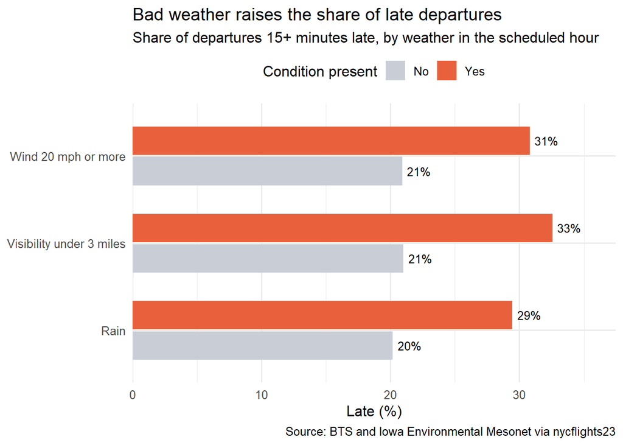

```r
p_weather <- ggplot(weather_effect, aes(x = pct_late, y = factor, fill = condition)) +
  geom_col(position = position_dodge(width = 0.7), width = 0.65) +
  geom_text(aes(label = paste0(round(pct_late), "%")),
            position = position_dodge(width = 0.7), hjust = -0.2, size = 3.4) +
  scale_fill_manual(values = c(No = grey, Yes = orange)) +
  scale_x_continuous(expand = expansion(mult = c(0, 0.15))) +
  labs(title = "Bad weather raises the share of late departures",
       subtitle = "Share of departures 15+ minutes late, by weather in the scheduled hour",
       x = "Late (%)", y = NULL, fill = "Condition present",
       caption = "Source: BTS and Iowa Environmental Mesonet via nycflights23") +
  theme(legend.position = "top")
p_weather
```

```r
ggsave("charts/late_by_weather.png", p_weather, width = 9, height = 4.5, dpi = 150, bg = "white")
```

Delays build up through the day: 8.9% of flights scheduled at 6:00 left late, against 32.5% at 19:00. Airlines differed widely, from 12.5% late for Republic Airline to 32.3% for JetBlue, and LaGuardia (18.7%) did better than Newark (23.4%) and JFK (23.1%). Bad weather also went with more late departures: 29.5% in rain against 20.2% in dry hours, 32.6% when visibility was under 3 miles and 30.8% in winds of 20 mph or more. But bad weather is rare: only 49,499 of 406,779 flights (12%) left in rain.

## 5. Separating time of day from the weather

Evening flights and stormy afternoons overlap, so the simple comparisons above can mix the two up. A logistic regression estimates the effect of each factor while holding the others constant: time of day, airline, airport, month, rain, low visibility and strong wind.

```r
model_data <- with_weather |>
  mutate(period  = cut(hour, breaks = c(0, 9, 12, 15, 18, 24), right = FALSE,
                       labels = c("5-8am", "9-11am", "12-2pm", "3-5pm", "6pm+")),
         airline = fct_lump_min(airline, min = 5000, other_level = "Other airlines"),
         month   = factor(month))

model <- glm(late ~ period + airline + origin + month + rain + low_vis + strong_wind,
             data = model_data, family = binomial)

# Odds ratios: above 1 means more likely to leave late than the comparison group
odds <- tidy(model) |>
  filter(str_detect(term, "period|rain|low_vis|strong_wind|origin")) |>
  mutate(odds_ratio = round(exp(estimate), 2),
         ci_low     = round(exp(estimate - 1.96 * std.error), 2),
         ci_high    = round(exp(estimate + 1.96 * std.error), 2)) |>
  select(term, odds_ratio, ci_low, ci_high)
odds
```

```
# A tibble: 9 x 4
  term            odds_ratio ci_low ci_high
  <chr>                <dbl>  <dbl>   <dbl>
1 period9-11am          1.6    1.55    1.64
2 period12-2pm          2.45   2.38    2.52
3 period3-5pm           3.45   3.35    3.54
4 period6pm+            4.45   4.33    4.57
5 originJFK             0.9    0.88    0.93
6 originLGA             0.84   0.82    0.86
7 rainTRUE              1.69   1.65    1.73
8 low_visTRUE           1.58   1.51    1.65
9 strong_windTRUE       1.42   1.36    1.47
```

Odds ratios are hard to explain to a manager, so the next step turns the model into plain percentages: what share of all flights would leave late if every flight were scheduled in the morning, or if it rained every hour, with everything else unchanged.

```r
what_if <- function(...) {
  newdata <- mutate(model_data, ...)
  round(100 * mean(predict(model, newdata = newdata, type = "response")), 1)
}
p <- function(x) factor(x, levels = levels(model_data$period))

scenarios <- tribble(
  ~factor,                       ~without,                          ~with,
  "Scheduled 6pm+ (vs 5-8am)",   what_if(period = p("5-8am")),      what_if(period = p("6pm+")),
  "Rain",                        what_if(rain = FALSE),             what_if(rain = TRUE),
  "Visibility under 3 miles",    what_if(low_vis = FALSE),          what_if(low_vis = TRUE),
  "Wind 20 mph or more",         what_if(strong_wind = FALSE),      what_if(strong_wind = TRUE)
) |>
  mutate(difference_pts = with - without,
         factor = fct_reorder(factor, difference_pts))
scenarios
```

```
# A tibble: 4 x 4
  factor                    without  with difference_pts
  <fct>                       <dbl> <dbl>          <dbl>
1 Scheduled 6pm+ (vs 5-8am)    10.4  32.1           21.7
2 Rain                         20.2  28.9            8.7
3 Visibility under 3 miles     21.1  28.7            7.6
4 Wind 20 mph or more          21.1  26.7            5.6
```

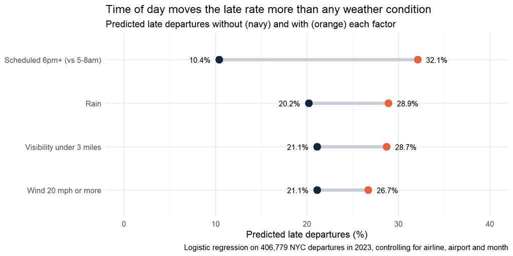

```r
p_model <- ggplot(scenarios, aes(y = factor)) +
  geom_segment(aes(x = without, xend = with, yend = factor), colour = grey, linewidth = 2) +
  geom_point(aes(x = without), colour = navy, size = 4) +
  geom_point(aes(x = with), colour = orange, size = 4) +
  geom_text(aes(x = with, label = paste0(with, "%")), hjust = -0.4, size = 3.4) +
  geom_text(aes(x = without, label = paste0(without, "%")), hjust = 1.4, size = 3.4) +
  scale_x_continuous(limits = c(0, 40)) +
  labs(title = "Time of day moves the late rate more than any weather condition",
          subtitle = "Predicted late departures without (navy) and with (orange) each factor",
       x = "Predicted late departures (%)", y = NULL,
       caption = "Logistic regression on 406,779 NYC departures in 2023, controlling for airline, airport and month")
p_model
```

```r
ggsave("charts/what_if.png", p_model, width = 9, height = 4.5, dpi = 150, bg = "white")
```

After holding airline, airport, month and weather constant, time of day matters most. If every flight were scheduled between 5 and 8am, the model predicts 10.4% would leave late; if every flight left at 6pm or later, 32.1% would, three times as many. Rain adds 8.7 percentage points, low visibility 7.6 and strong wind 5.6. Weather makes individual days worse, but the timetable affects every flight: delays carried forward through the day by the same aircraft and crews are the bigger, and more controllable, problem.

## 6. Limitations

- The data covers one year and three airports; other years or cities may differ.
- Weather is measured at the airport in the scheduled hour. Storms elsewhere in the network, which can delay the incoming aircraft, are not included.
- The model shows associations. The evening effect most likely comes from delays carried forward through the day, but the data does not record the cause of each delay.
- Cancelled flights (2.5%) are left out of the late rate, so the worst disruptions are not counted as delays.